# Portfolio 4: glarma

Justine Lang

2024-02-01

```r
knitr::opts_chunk$set(echo = TRUE, message = FALSE, warning = FALSE, results = FALSE)

library(glarma)
library(here)
library(dplyr)
library(tidyverse)
```

### Portfolio 4 Questions

Use the ‘glarma’ package in R: Use Bison data. AUer you create your models, visually compare the plots.

1. Which looks like the best fit?
2. Compare the AIC for the models. Which is actually the best fit?
3. Create a model with major events factored in and compare it with the best fit model identified in question 2. Is the model with major events a better fit? Some hints: Think about bison reproduction and how it would affect time lags: When do they reach sexual maturity? (2 years for females) How long is gestation? (~ 9 months) How often do bison breed? (Once a year)

What the package does: The GLARMA package takes data and models changes in population against explanatory variables. It is incredibly useful for time series data that is not normal.

```r
#load in the bison data
bison <- read_csv(here("forcast_glarma", "data", "bison_copy.csv"))
```

Here we’re working with Generalized Linear Autoregressive Moving Average Models, or GLARMA. Mostly going to be focusing on Poisson.

Need to add an intercept and needs to be a matrix.

```r
#add an intercept
bison$intercept<-as.integer(1)

#Identify variables
y <- bison$bison # y value is bison counts
x0 <- bison %>% select(intercept)
x0 <- as.matrix(x0) # turns x0 into a matrix
```

One vector: observational count data.

Time is needed. Can vary the time lag.

```r
#Create three glarma models that have a time lag of 1, 2, and 7
bison_null_lag <- glarma(y, x0, phiLags = c(1), type = "Poi", method = "FS",
                              residuals = "Pearson", maxit = 100, grad = 1e-6)

bison_null_lag2 <- glarma(y, x0, phiLags = c(2), type = "Poi", method = "FS",
                         residuals = "Pearson", maxit = 100, grad = 1e-6)

bison_null_lag7 <- glarma(y, x0, phiLags = c(7), type = "Poi", method = "FS",
                          residuals = "Pearson", maxit = 100, grad = 1e-6)
```

**1. Visually compare the plots. Which looks like the best fit?** (Commenting out for knitting purposes because of the error in the one plot)

```r
# plot.glarma(bison_null_lag) ###if you have an error in plot.window for the last plot, it's okay to ignore
```

```r
# plot.glarma(bison_null_lag2)
```

```r
# plot.glarma(bison_null_lag7)
```

**2. Compare the AIC for the models. Which is actually the best fit?**

```r
summary(bison_null_lag)
```

```r
summary(bison_null_lag2)
```

```r
summary(bison_null_lag7)
```

You can choose whether or not to factor major events into these models, including if you want to compare them to any models without. Also has to be a matrix. The major events used in this example are the reintroduction of wolves to Yellowstone and the 1988 Yellowstone Fire.

**3. Create a model with major events factored in and compare it with the best fit model identified in question 2. Is the model with major events a better fit?**

```r
#Add intercept and major events
bison$major_events <- as.integer(0)

bison$major_events[bison$year==1995] <- 1 # reintroduction of wolves to yellowstone NP

bison$major_events[bison$year==1988] <- 1 # 1988 Yellowstone Fire

#Identify variables
x1 <- bison %>% select(intercept, major_events) # x1 explanatory variables, presence of major events
x1 <- as.matrix(x1) #turns x1 into a matrix
```

```r
#Create the model with major events. Make the lag the same as the best fit model from question 2
bison_exp_lag <- glarma(y, x1, phiLags = c(2), type = "Poi", method = "FS",
                             residuals = "Pearson", maxit = 100, grad = 1e-6)
#summary
summary(bison_exp_lag)
```

**Extra if you’re feeling spry**

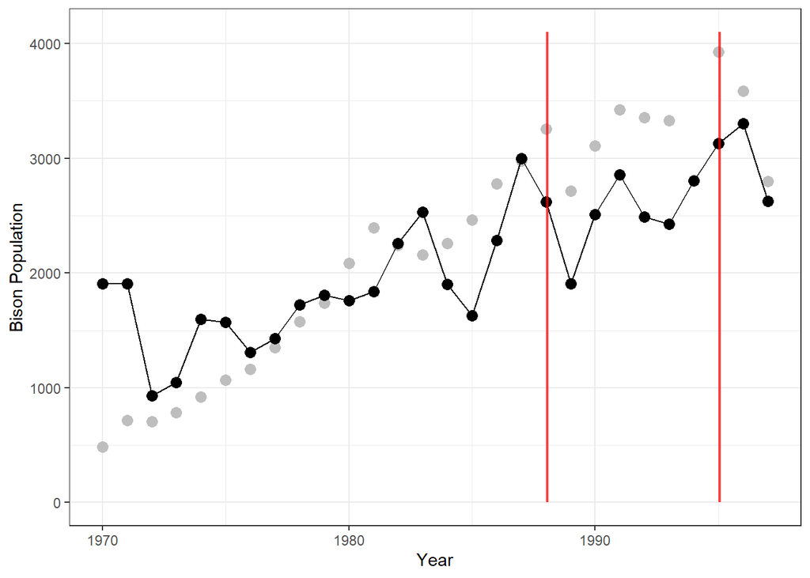

```r
bison_mod <- bison

bison_mod$est <- bison_exp_lag$fitted.values #adds fitted values

bison_plot<-ggplot(bison_mod, aes(x=year)) +
  geom_point(col="gray",aes(y=bison),size=3) +
  geom_point(col="black",aes(y=est),size=3) +
  geom_line(col="black",aes(y=est)) +
  labs(x="Year", y="Bison Population") +
  ylim(0,4100) + xlim(1970,1997)+
  theme_bw()

#Adds two red horizontal lines for the occurrence of fire and reintroduction of wolves
bison_plot <-bison_plot +
  annotate("rect", xmin = 1988, xmax =1988.1, ymin = 0, ymax = 4100, alpha = .75,fill = "red") +
  annotate("rect", xmin = 1995, xmax =1995.1, ymin = 0, ymax = 4100, alpha = .75,fill = "red")

bison_plot
```